# Supplemental materials to ‘POnSS: efficient and accurate annotation’

Joe Rodd

# Analysis 0: Simulations of conventional coefficients of reliability

We started with the dataset of word annotations segmented by the baseline method. For each individual word token, the median word onset time across all annotators was calculated. The same was done for the offset times. For each segmentation, the difference between the segmented onset and offset times and the median onset and offset times was calculated. The distribution of these divergence times is shown in panel 1 of Figure S1. The other distributions in Figure S1 show the same data, but with some segmentations replaced by times sampled from a predefined normal distribution. The $\sigma$ parameter of that distribution was varied between 0 and 100 ms, as was the proportion of items replaced. This is indicated in the labels above each distribution. If the re-sampling distribution had low $\sigma$, then the distribution becomes ‘tighter’, for instance in distribution 5, where nearly all the probability mass falls within the green region, which indicates times between -5 ms and 5 ms around the median segmentation. If the re-sampling distribution had a higher $\sigma$, then the distribution widens.

From these simulations, we conclude that none of Krippendorff’s alpha, ICC or percentage agreement offers a sufficiently sensitive way to assess the reliability of speech segmentation data, that can differentiate between samples of both well-segmented and poorly-segmented speech data.

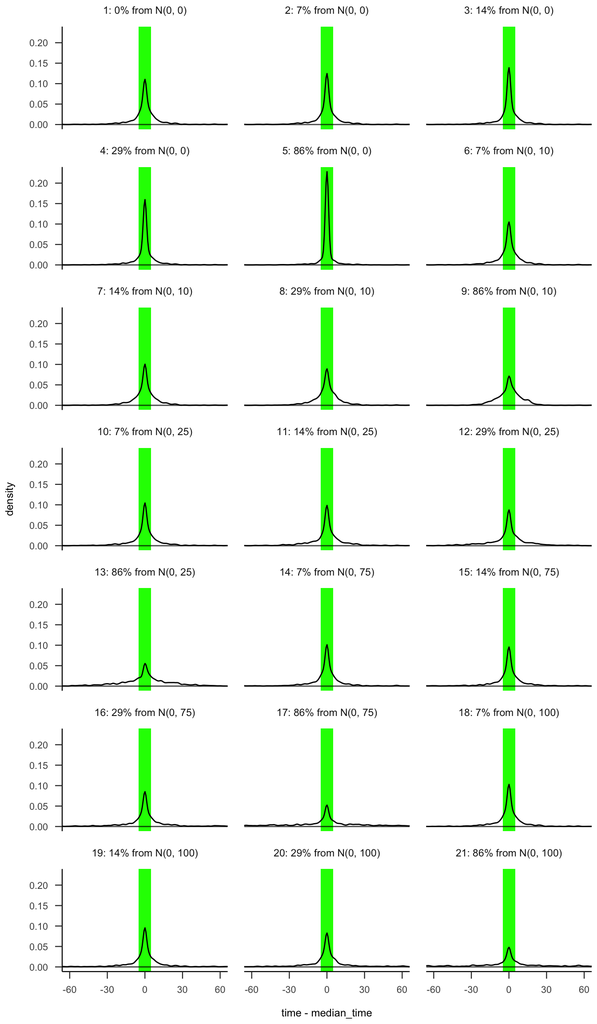

**Figure S1** A sample of distributions used in the simulation investigation to select a reliability coefficient. The green section indicates a region from -5 ms to 5 ms. More distributions are illustrated in the supplementary materials.

```r
distributions_to_illustrate_key <- bind_rows(data.frame(percentage=0,severity=0),
                                             expand.grid(percentage = c(50,100,200,600),
                                           severity = c(0,10,25,75,100))) %>%
  mutate(sample = row_number(),
         sample_long = paste0(row_number(),": ",round(percentage / 7 ),"% from N(0, ",severity,")"))

distributions_to_illustrate_key$sample_long <- ordered(distributions_to_illustrate_key$sample_long,levels=distributions_to_illustrate_key$sample_long)

distributions_to_illustrate <- distributions_to_illustrate_key %>% group_by(sample,sample_long,percentage,severity) %>% do({
  x = .[1,]
  distributions_simulated %>% filter(percentage == x$percentage, severity == x$severity)})


distributions_illustration_all <- distributions_to_illustrate  %>% gather(key = "annotator",value = "time",c(7:13)) %>%
  ggplot()+
    geom_rect(aes(xmin=-5,xmax=5,ymin=-Inf,ymax=Inf),fill="green",alpha=0.2)+
    geom_hline(yintercept=0,alpha=0.7)+
  stat_density(aes(x=time-median_time),geom="line",bw=1.19,n=1000)+
  coord_cartesian(xlim=c(-60,60))+facet_wrap(~sample_long,ncol = 3)+theme(strip.background = element_rect(fill = "#FFFFFF"))

distributions_illustration_restricted <- distributions_to_illustrate %>% filter(sample %in% c(1,5, 11,13,20,21))  %>% gather(key = "annotator",value = "time",c(7:13)) %>%
  ggplot()+
    geom_rect(aes(xmin=-5,xmax=5,ymin=-Inf,ymax=Inf),fill="green",alpha=0.2)+
    geom_hline(yintercept=0,alpha=0.7)+
  stat_density(aes(x=time-median_time),geom="line",bw=1.19,n=1000)+
  coord_cartesian(xlim=c(-60,60))+facet_wrap(~sample_long,ncol = 3)+theme(strip.background = element_rect(fill = "#FFFFFF"))

distributions_illustration_all
```

```r
if(!file.exists("cached/alphas_simulated.rds")){
  alphas_simulated <- distributions_simulated %>% group_by(percentage,severity) %>% do({
    data.frame(alpha = alpha_function(.,T,5:11))
  })
  saveRDS(alphas_simulated,"cached/alphas_simulated.rds")
} else {
  alphas_simulated <- read_rds("cached/alphas_simulated.rds")
}

if(!file.exists("cached/iccs_simulated.rds")){
  iccs_simulated <- distributions_simulated %>% group_by(percentage,severity) %>% do({
    data.frame(icc = icc_function(.,T,5:11))
  })
  saveRDS(iccs_simulated,"cached/iccs_simulated.rds")
} else {
  iccs_simulated <- read_rds("cached/iccs_simulated.rds")
}

if(!file.exists("cached/agree_simulated_5.rds")){
  agree_simulated_5 <- distributions_simulated %>% group_by(percentage,severity) %>% do({
    data.frame(agree = agree_function(.,T,5:11,5))
  })
  saveRDS(agree_simulated_5,"cached/agree_simulated_5.rds")
} else {
  agree_simulated_5 <- read_rds("cached/agree_simulated_5.rds")
}

if(!file.exists("cached/agree_simulated_10.rds")){
  agree_simulated_10 <- distributions_simulated %>% group_by(percentage,severity) %>% do({
    data.frame(agree = agree_function(.,T,5:11,10))
  })
  saveRDS(agree_simulated_10,"cached/agree_simulated_10.rds")
} else {
  agree_simulated_10 <- read_rds("cached/agree_simulated_10.rds")
}

if(!file.exists("cached/agree_simulated_20.rds")){
  agree_simulated_20 <- distributions_simulated %>% group_by(percentage,severity) %>% do({
    data.frame(agree = agree_function(.,T,5:11,20))
  })
  saveRDS(agree_simulated_20,"cached/agree_simulated_20.rds")
} else {
  agree_simulated_20 <- read_rds("cached/agree_simulated_20.rds")
}

agree_simulated <- bind_rows(agree_simulated_5 %>% mutate(tolerance = 5),
                             agree_simulated_10 %>% mutate(tolerance = 10),
                             agree_simulated_20 %>% mutate(tolerance = 20))

if(!file.exists("cached/mean_corr_simulated.rds")){
  mean_corr_simulated <- distributions_simulated %>% group_by(percentage,severity) %>% do({
    data.frame(Mcorr = mean_corr_function(.,T,5:11))
  })
  saveRDS(mean_corr_simulated,"cached/mean_corr_simulated.rds")
} else {
  mean_corr_simulated <- read_rds("cached/mean_corr_simulated.rds")
}


if(!file.exists("cached/alphas_simulated_normalised.rds")){
  alphas_simulated_normalised <- distributions_simulated %>% group_by(percentage,severity) %>% do({
    data.frame(alpha = alpha_function_normalised(.,T,5:11))
  })
  saveRDS(alphas_simulated_normalised,"cached/alphas_simulated_normalised.rds")
} else {
  alphas_simulated_normalised <- read_rds("cached/alphas_simulated_normalised.rds")
}

if(!file.exists("cached/iccs_simulated_normalised.rds")){
  iccs_simulated_normalised <- distributions_simulated %>% group_by(percentage,severity) %>% do({
    data.frame(icc = icc_function_normalised(.,T,5:11))
  })
  saveRDS(iccs_simulated_normalised,"cached/iccs_simulated_normalised.rds")
} else {
  iccs_simulated_normalised <- read_rds("cached/iccs_simulated_normalised.rds")
}
```

```r
alpha_figure_restricted <- alphas_simulated %>% filter(severity!=0) %>% ggplot()+
    geom_tile(aes(x=percentage/7,y=severity,fill=alpha),data = . %>% filter(severity < 10))+
    geom_tile(aes(x=percentage/7,y=severity,fill=alpha),data = . %>% filter(severity >= 10,severity <= 20))+
    geom_tile(aes(x=percentage/7,y=severity,fill=alpha),data = . %>% filter(severity >= 20))+scale_fill_viridis_c(option="D")+
    geom_point(aes(x=percentage/7,y=severity),size=4,colour="white",data=distributions_to_illustrate_key %>% filter(sample %in% c(c(1,5, 11,13,20,21))))+
    geom_text(aes(x=percentage/7,y=severity,label=sample),size=2,data=distributions_to_illustrate_key %>% filter(sample %in% c(c(1,5, 11,13,20,21))))+
  scale_y_continuous("resampling distribution\nsigma (ms)")+
  scale_x_continuous("% segmentations replaced")

# alpha_figure_restricted
```

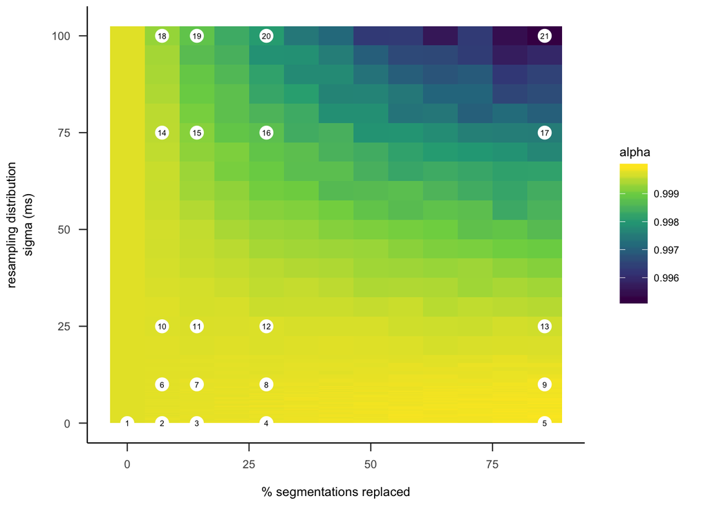

**Figure S2** Variation in Krippendorff’s alpha (colours) by the sigma of the resampling distribution (y-axis) and the percentage of segmentations replaced (x-axis). Numbered points show the locations of the sample distributions shown in Figure S1.

```r
alpha_figure <- alphas_simulated %>% filter(severity!=0) %>% ggplot()+
    geom_tile(aes(x=percentage/7,y=severity,fill=alpha),data = . %>% filter(severity < 10))+
    geom_tile(aes(x=percentage/7,y=severity,fill=alpha),data = . %>% filter(severity >= 10,severity <= 20))+
    geom_tile(aes(x=percentage/7,y=severity,fill=alpha),data = . %>% filter(severity >= 20))+scale_fill_viridis_c(option="D")+
    geom_point(aes(x=percentage/7,y=severity),size=4,colour="white",data=distributions_to_illustrate_key)+
    geom_text(aes(x=percentage/7,y=severity,label=sample),size=2,data=distributions_to_illustrate_key)+
  scale_y_continuous("resampling distribution\nsigma (ms)")+
  scale_x_continuous("% segmentations replaced")

alpha_figure
```

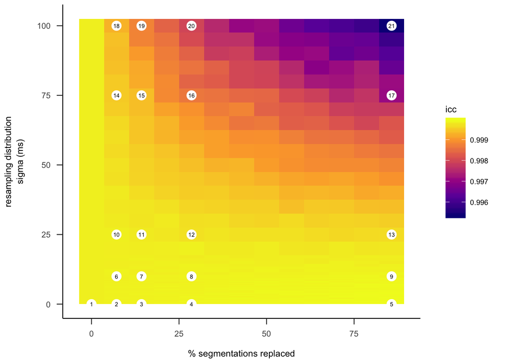

**Figure S3** Variation in ICC (colours) by the same factors

```r
icc_figure <- iccs_simulated %>% filter(severity!=0) %>% ggplot()+
    geom_tile(aes(x=percentage/7,y=severity,fill=icc),data = . %>% filter(severity < 10))+
    geom_tile(aes(x=percentage/7,y=severity,fill=icc),data = . %>% filter(severity >= 10,severity <= 20))+
    geom_tile(aes(x=percentage/7,y=severity,fill=icc),data = . %>% filter(severity >= 20))+scale_fill_viridis_c(option="C")+
    geom_point(aes(x=percentage/7,y=severity),size=4,colour="white",data=distributions_to_illustrate_key)+
    geom_text(aes(x=percentage/7,y=severity,label=sample),size=2,data=distributions_to_illustrate_key)+
  scale_y_continuous("resampling distribution\nsigma (ms)")+
  scale_x_continuous("% segmentations replaced")

icc_figure
```

```r
agreement_figure_two <- agree_simulated %>% filter(severity!=0,tolerance %in% c(10,20)) %>% ggplot()+
    geom_tile(aes(x=percentage/7,y=severity,fill=agree),data = . %>% filter(severity < 10))+
    geom_tile(aes(x=percentage/7,y=severity,fill=agree),data = . %>% filter(severity >= 10,severity <= 20))+
    geom_tile(aes(x=percentage/7,y=severity,fill=agree),data = . %>% filter(severity >= 20))+scale_fill_viridis_c("% agreement",option="B")+
    geom_point(aes(x=percentage/7,y=severity),size=4,colour="white",data=distributions_to_illustrate_key %>% filter(sample %in% c(c(1,5, 11, 13,20,21))))+
    geom_text(aes(x=percentage/7,y=severity,label=sample),size=2,data=distributions_to_illustrate_key %>% filter(sample %in% c(c(1,5, 11,13,20,21))))+
    facet_wrap(~tolerance,nrow = 1,labeller = as_labeller(c(`10`="tolerance: 10 ms",`20`="tolerance: 20 ms")))+theme(strip.background = element_rect(fill = "#FFFFFF"))+
  scale_y_continuous("resampling distribution\nsigma (ms)")+
  scale_x_continuous("% segmentations replaced")+
  theme(legend.position = "bottom")
```

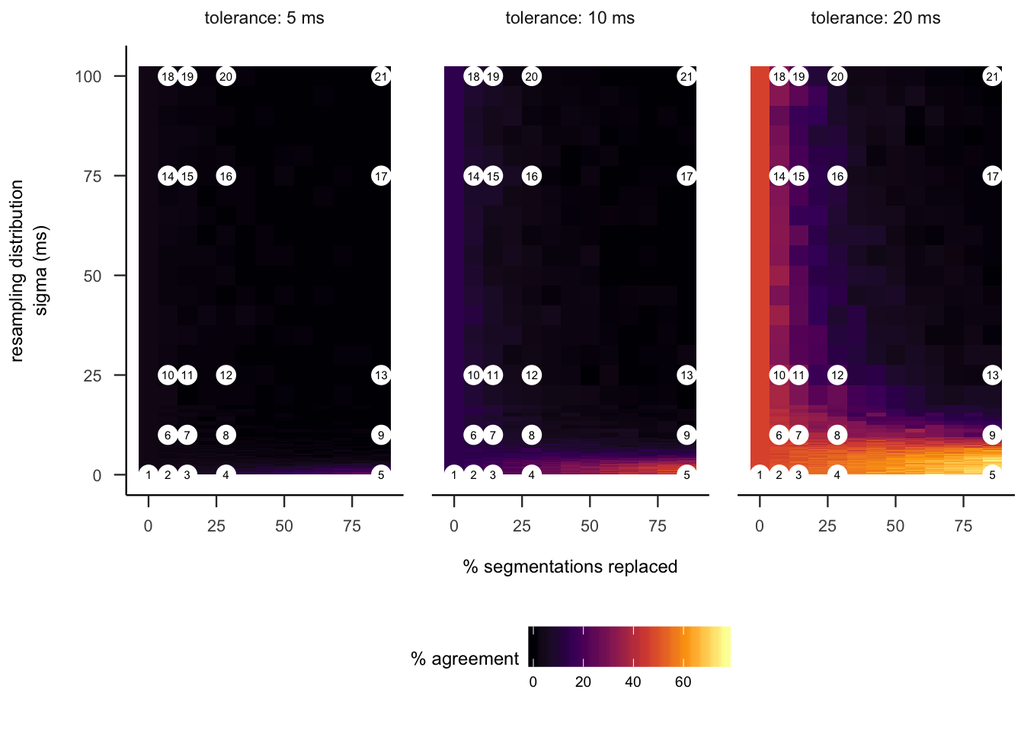

**Figure S4** Variation in percentage agreement (colours) by the same factors, over three possible tolerances

```r
agreement_figure <- agree_simulated %>% filter(severity!=0) %>% ggplot()+
    geom_tile(aes(x=percentage/7,y=severity,fill=agree),data = . %>% filter(severity < 10))+
    geom_tile(aes(x=percentage/7,y=severity,fill=agree),data = . %>% filter(severity >= 10,severity <= 20))+
    geom_tile(aes(x=percentage/7,y=severity,fill=agree),data = . %>% filter(severity >= 20))+scale_fill_viridis_c("% agreement",option="B")+
    geom_point(aes(x=percentage/7,y=severity),size=4,colour="white",data=distributions_to_illustrate_key)+
    geom_text(aes(x=percentage/7,y=severity,label=sample),size=2,data=distributions_to_illustrate_key)+
    facet_wrap(~tolerance,nrow = 1,labeller = as_labeller(c(`5`="tolerance: 5 ms",`10`="tolerance: 10 ms",`20`="tolerance: 20 ms")))+theme(strip.background = element_rect(fill = "#FFFFFF"))+
  scale_y_continuous("resampling distribution\nsigma (ms)")+
  scale_x_continuous("% segmentations replaced")+
  theme(legend.position = "bottom")

agreement_figure
```

```r
save(distributions_illustration_all,distributions_illustration_restricted,alpha_figure_restricted,icc_figure,agreement_figure_two,file="report_data/simulated_agreement_metrics.Rdata")
```

# Analysis 1: Reliability of segmented event times

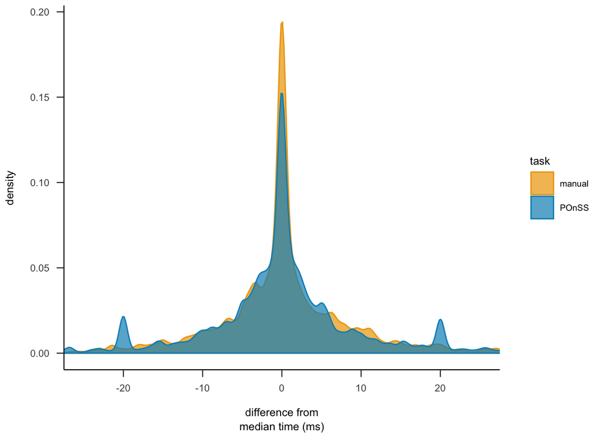

**Figure S5** The observed distributions of the difference between segmented tmes and the median segmentation for each word, for POnSS and manual annotation modalities (colours)

```r
combined_onsets_offsets <- full_join(manual_onsets_offsets %>% mutate(Carlijn = Carlijn * 1000,
                                                                      Dennis = Dennis * 1000,
                                                                      Esther = Esther * 1000,
                                                                      Inge = Inge * 1000,
                                                                      Nikki = Nikki * 1000,
                                                                      Rosemarije = Rosemarije * 1000,
                                                                      Sjaroes = Sjaroes * 1000),distributed_onsets_offsets,by=c("experimental_trial_id","word_label"="label","event","experimental_condition"))

combined_onsets_offsets$median_time <- matrixStats::rowMedians(as.matrix(combined_onsets_offsets[,c(3:9,14:63)]),na.rm = T)

combined_onsets_offsets_long <- combined_onsets_offsets %>% ungroup() %>% gather(key = "annotator",value = "time",c(3:9,14:63))

combined_onsets_offsets_long <- combined_onsets_offsets_long %>% filter(!is.na(time))

# combined_onsets_offsets_long %>% group_by(task) %>% summarise(n=n(),
#                                                               within_20 = sum(ifelse(abs(time-median_time)<20,1,0))) %>%
#   mutate(percent = within_20 / n)

combined_onsets_offsets_long <- combined_onsets_offsets_long %>% mutate(task = ifelse(annotator %in% c("Carlijn","Dennis","Esther","Inge","Nikki","Rosemarije","Sjaroes"),"manual","POnSS"),
                                                                        annotator = str_split(annotator," ",simplify = T)[,1],
                                                                        annotator = recode(annotator,"1" = "Joe",
                                                                                           "17" = "Carlien",
                                                                                           "20" = "Nikki",
                                                                                           "21"="Moniek",
                                                                                           "22" = "Jessica",
                                                                                           "23" = "Zina",
                                                                                           "26" = "Annelies",
                                                                                           "41" = "Rosemarije",
                                                                                           "42" = "Sanne"
                                                                                           ))

set.seed(456)
test_set <- combined_onsets_offsets_long %>% group_by(event,experimental_condition,task) %>% sample_n(400) %>% mutate(time_diff=time-median_time)

test_set$experimental_condition <- as.factor(test_set$experimental_condition)
test_set$task <- as.factor(test_set$task)
test_set$item_index <- seq(1,nrow(test_set))

observed_deviations <-  test_set %>% ggplot()+
  geom_density(aes(x=time-median_time,fill=task,colour=task),alpha=0.7,bw=0.5,n=50^2)+
  coord_cartesian(xlim=c(-25,25))+
  scale_x_continuous("difference from\nmedian time (ms)")+
  # scale_y_discrete("modality")+
  scale_fill_manual(values = c("POnSS"="#008FC1","manual" = "#EEA300"))+
  scale_colour_manual(values = c("POnSS"="#008FC1","manual" = "#EEA300"))

observed_deviations
```

### Particle swarm optimisation

We construct subsets of the test dataset, that varied in the proportion of each condition (speaking rate, task) represented. For the rate conditions, we set the proportions of each rate to approximately 10% to approximately 80%, in steps of 10%. For the task conditions, we set the proportions of manual annotation to between 20% and 80%, again in steps of 10%. The different levels were exhaustively combined, meaning that 252 samples were constructed.

```r
sample_optimisations <- bind_rows(lapply(list.files("grid_results","sample_optimisations\\d+"),function(x){readRDS(paste0("grid_results/",x))}))

sample_optimisations <- sample_optimisations %>% mutate(weight = 1-KL)

calculate_thetas <- function(thetaA,thetaB){
  list(theta1 = thetaA,
       theta2 = ((1 - thetaA) * thetaB),
       theta3 = 1 - (thetaA + ((1 - thetaA) * thetaB)))
}

sample_optimisations$theta1 <- calculate_thetas(sample_optimisations$thetaA,sample_optimisations$thetaB)$theta1
sample_optimisations$theta2 <- calculate_thetas(sample_optimisations$thetaA,sample_optimisations$thetaB)$theta2
sample_optimisations$theta3 <- calculate_thetas(sample_optimisations$thetaA,sample_optimisations$thetaB)$theta3

long_sample_optimisations <- left_join(sample_optimisations %>% select(realised_456,realised_646,realised_915,realised_manual,realised_POnSS,weight,sigma1,sigma2,sigma3) %>% gather("distribution","sigmavalue",sigma1,sigma2,sigma3) %>% mutate(distribution=recode(distribution,sigma1="narrow",sigma2="medium",sigma3="wide")),
                                       sample_optimisations %>% select(realised_456,realised_646,realised_915,realised_manual,realised_POnSS,weight,theta1,theta2,theta3) %>% gather("distribution","thetavalue",theta1,theta2,theta3) %>% mutate(distribution=recode(distribution,theta1="narrow",theta2="medium",theta3="wide")))

long_sample_optimisations$weight_theta <- long_sample_optimisations$weight * long_sample_optimisations$thetavalue

long_sample_optimisations$distribution <- as.factor(long_sample_optimisations$distribution)
long_sample_optimisations$distribution <- relevel(long_sample_optimisations$distribution,"medium")
contrasts(long_sample_optimisations$distribution) <- contr.sum(3)
```

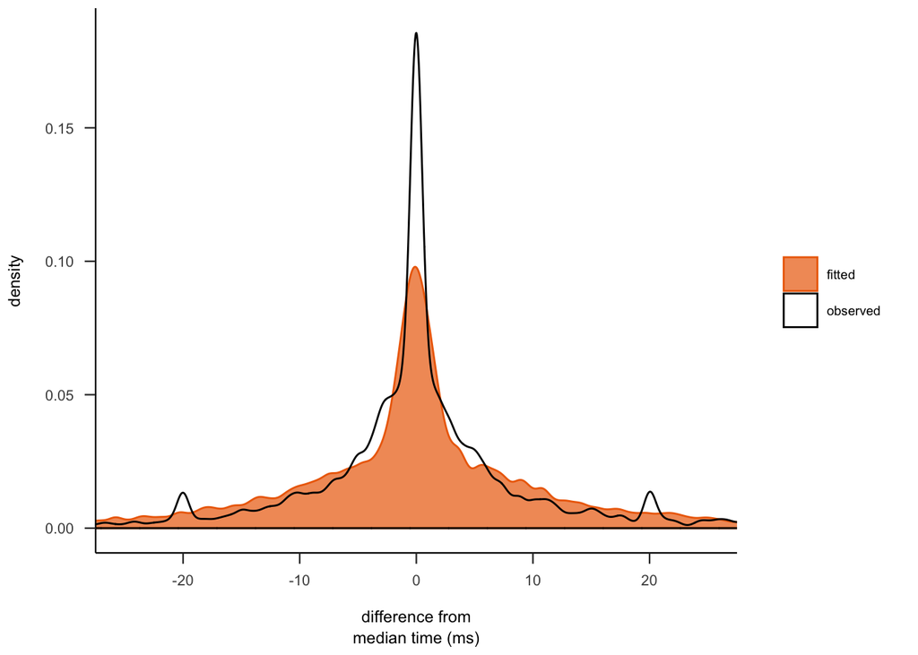

**Figure S6** An example of the optimised mixture-model fit (orange) to the observed distribution of one of the samples (black line)

```r
hydro_fit_plot <- readRDS("grid_results/example_hydro_fit_plot.rds")

hydro_fit_plot
```

We then used PSO to parametrically fit the distributions in each subset, with KL as score function.

Boundaries were set for the space to be searched by PSO. These boundaries are set to ensure that one distribution fits the tight peak, a second distribution fits the shoulders, and the third fits the tails, though they overlap enough that if the model decided to, it could reject our ordering. The thetas are parmeterised such that the first (thetaA) decides the proportion of the first distribution vs the second and third together. The second theta parameter (thetaB) decides the proportion of the second distribution vs the third distribution, within what is left over after thetaA. This way, it is unnecessaary to code the constraint that the three resulting thetas should sum to 1.0.

This analysis is available in `optimize_PSO.R`.

### Inferential model (model 1)

We fitted an inferential model over the sigma values identified by PSO, to examine what the impact of the different rate conditions and the task was on the fitted sigmas.

```r
f_sigma_reliability <- bf(sigmavalue|weights(weight_theta) ~ 1 + realised_POnSS*distribution+realised_456*distribution+realised_915*distribution,
                    sigma~distribution,
                    nu~distribution,
                    family="student")


m_sigma_reliability <- brm(f_sigma_reliability,
    data  = long_sample_optimisations,
    prior = c(prior(normal(0,5),class="b")),
    file="model_fits/m_sigma_reliability",
    chains = 6,
    cores = 2,
    iter=8000
    )
```

```r
fes_sigma_reliability <- summary(m_sigma_reliability)$fixed

fes_sigma_reliability %>% kable(digits=3)
```

|  | Estimate | Est.Error | l-95% CI | u-95% CI | Rhat | Bulk_ESS | Tail_ESS |
| --- | --- | --- | --- | --- | --- | --- | --- |
| Intercept | 9.786 | 0.129 | 9.533 | 10.037 | 1.001 | 8317 | 11972 |
| sigma_Intercept | 0.631 | 0.007 | 0.617 | 0.644 | 1.000 | 27087 | 16860 |
| nu_Intercept | 6.259 | 0.409 | 5.511 | 7.121 | 1.001 | 22255 | 17526 |
| realised_POnSS | -0.383 | 0.147 | -0.669 | -0.093 | 1.000 | 11221 | 14373 |
| distribution1 | -4.780 | 0.151 | -5.077 | -4.484 | 1.000 | 10186 | 13400 |
| distribution2 | -8.806 | 0.131 | -9.061 | -8.547 | 1.001 | 8354 | 11916 |
| realised_456 | 2.575 | 0.173 | 2.233 | 2.917 | 1.001 | 10001 | 14246 |
| realised_915 | -0.109 | 0.175 | -0.459 | 0.233 | 1.001 | 10719 | 14476 |
| realised_POnSS:distribution1 | -0.005 | 0.177 | -0.347 | 0.339 | 1.000 | 16499 | 16923 |
| realised_POnSS:distribution2 | 0.423 | 0.150 | 0.127 | 0.714 | 1.000 | 11727 | 13939 |
| distribution1:realised_456 | -2.338 | 0.203 | -2.737 | -1.944 | 1.000 | 13597 | 16316 |
| distribution2:realised_456 | -2.690 | 0.176 | -3.037 | -2.345 | 1.001 | 10111 | 14042 |
| distribution1:realised_915 | 0.296 | 0.205 | -0.106 | 0.697 | 1.000 | 14193 | 16758 |
| distribution2:realised_915 | 0.113 | 0.178 | -0.234 | 0.464 | 1.001 | 10845 | 15317 |
| sigma_distribution1 | -0.153 | 0.011 | -0.174 | -0.133 | 1.000 | 17049 | 17058 |
| sigma_distribution2 | -1.256 | 0.010 | -1.275 | -1.238 | 1.000 | 18921 | 17749 |
| nu_distribution1 | -0.416 | 0.673 | -1.654 | 1.018 | 1.000 | 19035 | 15532 |
| nu_distribution2 | 0.089 | 0.673 | -1.136 | 1.510 | 1.000 | 18525 | 15006 |

```r
# bayes_R2(m_sigma_reliability)
```

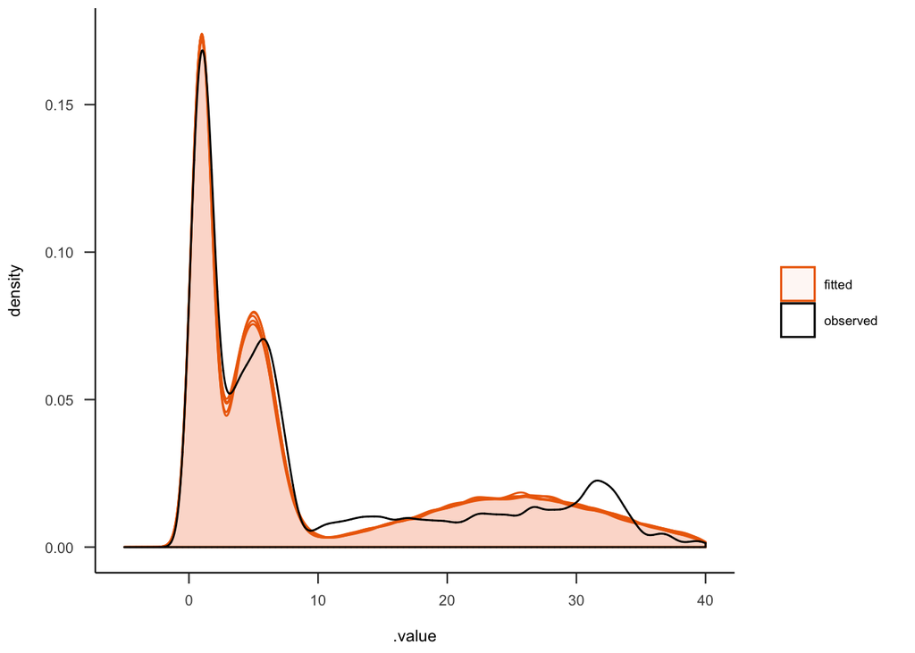

**Figure S7** The posterior-predictive plot for model 1

```r
pp_data <- function (object, type, nsamples, group = NULL, x = NULL, newdata = NULL,
          resp = NULL, subset = NULL, ...)
{
  y <- brms:::get_y(object, resp = resp, newdata = object$data)
  subset <- brms:::subset_samples(object, NULL, 5)
  pred_args <- list(object, newdata = object$data, resp = NULL,
                    subset = subset, sort = FALSE, summary = FALSE)
  yrep <- do_call("predict", pred_args)

  return(list(y=y,
              yrep=yrep))
}

if(!file.exists("cached/pp_data_reliability.rds")){
  pp_data_reliability <- pp_data(m_sigma_reliability)
  saveRDS(pp_data_reliability,"cached/pp_data_reliability.rds")
} else {
  pp_data_reliability <- readRDS("cached/pp_data_reliability.rds")
}


pp_plot_data_reliability <- data.frame(y = m_sigma_reliability$data$sigmavalue,
                           yrep_1 = pp_data_reliability$yrep[1,],
                           yrep_2 = pp_data_reliability$yrep[2,],
                           yrep_3 = pp_data_reliability$yrep[3,],
                           yrep_4 = pp_data_reliability$yrep[4,],
                           yrep_5 = pp_data_reliability$yrep[5,]) %>% gather(repetition,.value,y,yrep_1,yrep_2,yrep_3,yrep_4,yrep_5)


pp_plot_reliability <- pp_plot_data_reliability %>% filter(repetition!="y",.value>-5,.value<40) %>% ggplot()+
  geom_density(aes(x=.value,group=repetition,colour="fitted",fill="fitted"),alpha=0.05,bw=0.6,n=100^2)+
  geom_density(aes(x=.value,colour="observed",fill="observed"),alpha=0,bw=0.6,n=100^2,data=pp_plot_data_reliability %>% filter(repetition=="y",.value>-5,.value<-40))+
  coord_cartesian(xlim=c(-5,40))+
  scale_colour_manual("",values=c("observed"="#000000","fitted"="#ED6B06"))+
  scale_fill_manual("",values=c("observed"="#FFFFFF","fitted"="#ED6B06"))+
  scale_alpha_manual("",values=c("observed"="0","fitted"="0.7"))

pp_plot_reliability
```

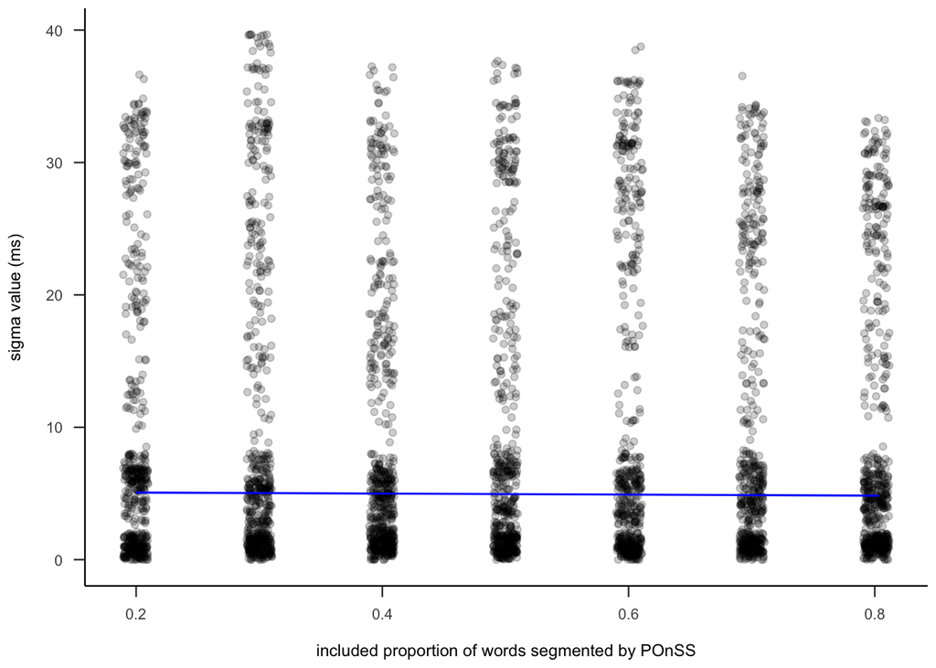

**Figure S7** The marginal effects plot for model 1

```r
marginal_effect <- marginal_effects(m_sigma_reliability,"realised_POnSS")$realised_POnSS

ggplot()+geom_point(aes(x=jitter(realised_POnSS,factor=500),y=sigmavalue),data=m_sigma_reliability$data %>% sample_n(4000),alpha=0.2)+
  geom_ribbon(aes(x=realised_POnSS,ymax=upper__,ymin=lower__),data=marginal_effect,alpha=0.2,fill="blue")+
  geom_line(aes(x=realised_POnSS,y=estimate__),data=marginal_effect,colour="blue")+
  scale_y_continuous("sigma value (ms)")+
  scale_x_continuous("included proportion of words segmented by POnSS")
```

Let’s have a look at the distributions of the model coefficients for the sigma parameters.

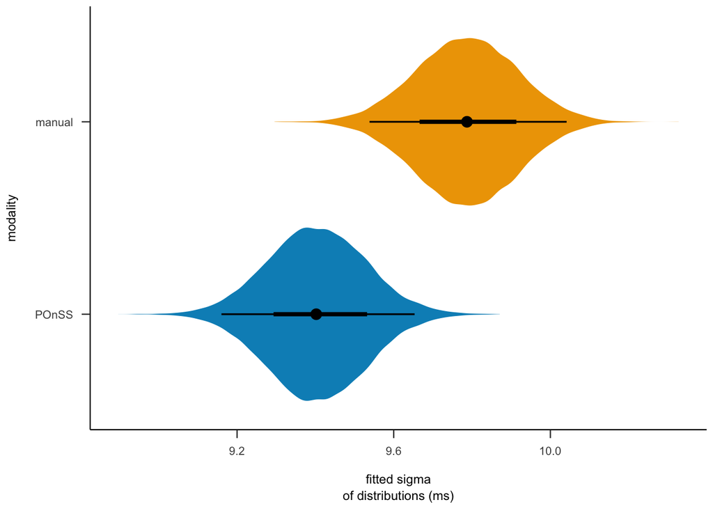

**Figure S8** Solid violins show the posteriors of Model 1 for the effect of modality on the sigma, with median (points), 95% HDIs (thin black lines) and 66% HDIs (thick black lines)

```r
plotdata_reliability_task <- bind_rows(
  m_sigma_reliability %>% spread_draws(b_Intercept,b_realised_POnSS) %>%
  group_by(.chain,.iteration,.draw) %>%
  transmute(POnSS = b_Intercept+b_realised_POnSS,
         manual = b_Intercept) %>% gather(task,.value,POnSS,manual))

plot_reliability_task <- plotdata_reliability_task %>%
  ggplot(mapping = aes(y = task,x=.value,group=task,fill=task)) +
  geom_eyeh(point_interval = median_hdci)+
  # scale_alpha_continuous(expression(theta),limits =c(0,1))+
  scale_x_continuous("fitted sigma\nof distributions (ms)")+
  scale_y_discrete("modality",limits=c("POnSS","manual"))+
  scale_fill_manual(values = c("POnSS"="#008FC1","manual" = "#EEA300"),guide=F)

plot_reliability_task
```

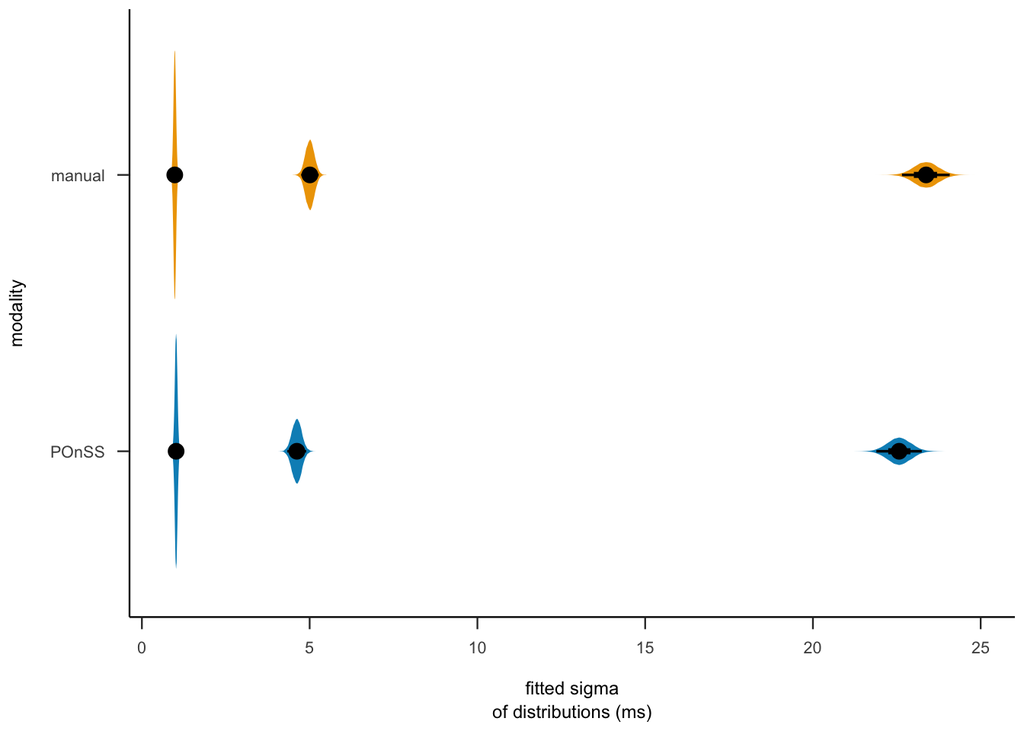

**Figure S9** Solid violins show the posteriors of Model 1 for the effect of modality and the interaction between modality and component on the sigma, with median (points), 95% HDIs (thin black lines) and 66% HDIs (thick black lines)

```r
plotdata_reliability_task_distributions <- m_sigma_reliability %>% spread_draws(b_Intercept,b_realised_POnSS,b_distribution1,b_distribution2,`b_realised_POnSS:distribution1`,`b_realised_POnSS:distribution2`) %>%
  group_by(.chain,.iteration,.draw) %>%
  transmute(POnSS_medium = b_Intercept+b_distribution1+b_realised_POnSS+`b_realised_POnSS:distribution1`,
            manual_medium = b_Intercept+b_distribution1,
            POnSS_narrow = b_Intercept+b_distribution2+b_realised_POnSS+`b_realised_POnSS:distribution2`,
            manual_narrow = b_Intercept+b_distribution2,
            POnSS_wide = b_Intercept-b_distribution1-b_distribution2+b_realised_POnSS-`b_realised_POnSS:distribution1`-`b_realised_POnSS:distribution2`,
            manual_wide = b_Intercept-b_distribution1-b_distribution2) %>% gather(task_component,.value,POnSS_medium,manual_medium,POnSS_narrow,manual_narrow,POnSS_wide,manual_wide) %>%
  mutate(task = str_split(task_component,"_",simplify = T)[,1],
         component = str_split(task_component,"_",simplify = T)[,2])

plot_reliability_task_distributions <- plotdata_reliability_task_distributions %>%
  ggplot(mapping = aes(y = task,x=.value,group=paste(task,component),fill=task)) +
  geom_eyeh(point_interval = median_hdci)+
  # scale_alpha_continuous(expression(theta),limits =c(0,1))+
  scale_x_continuous("fitted sigma\nof distributions (ms)")+
  scale_y_discrete("modality",limits=c("POnSS","manual"))+
  scale_fill_manual(values = c("POnSS"="#008FC1","manual" = "#EEA300"),guide=F)

plot_reliability_task_distributions
```

```r
interaction_wide <- matrix(0-fes_sigma_reliability["realised_POnSS:distribution2",]-fes_sigma_reliability["realised_POnSS:distribution1",],nrow=1)

colnames(interaction_wide) <- colnames(fes_sigma_reliability)
rownames(interaction_wide) <- "interaction wide"

save(observed_deviations,plot_reliability_task,fes_sigma_reliability,interaction_wide,hydro_fit_plot,file="report_data/reliability_task.RData")
```

# Analysis 2: Speed of methods

The following plot compares the time taken to have 5000 annotated words by the manual method, and by using POnSS. It is much quicker to use POnSS (excluding set up time).

Around 5 percent of word candidates are ultimately rejected (don’t make it into the finished dataset).

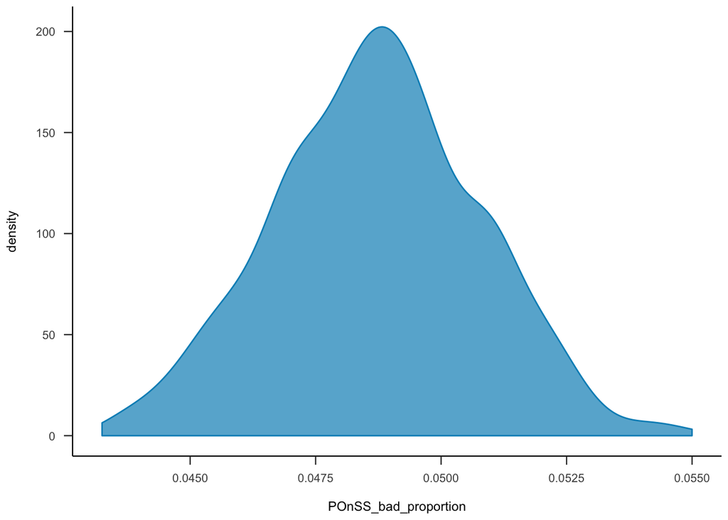

**Figure S10** The resampled proportion of words that ultimately get rejected, using POnSS.

```r
manual_annotations <- readRDS("manual_annotations.RDS")

if(!file.exists("time_investment_draws.rds")){
  draw_manual <- function(draw){
  set.seed(456+draw)
  e <- manual_annotations %>% sample_n(5000) %>% summarise(total_time_investment = as.numeric(lubridate::dseconds(as.numeric(sum(busy_with_word,na.rm = T)))))
  e
}


 draw_distributed <- function(draw){
  good_words_count <- 0
  attempt = 5000
  while(good_words_count != 5000) {
    if( 5000 - good_words_count > 100){
      attempt = attempt + 50
    } else if(5000 - good_words_count > 0){
      attempt = attempt + 1
    } else if(5000 - good_words_count < -100){
      attempt = attempt - 50
    } else if(5000 - good_words_count < 0){
      attempt = attempt - 1
    }
    set.seed(456+draw)
    e = durations_distributed %>% filter(total_busy_seconds_evaluation < quantile(total_busy_seconds_evaluation,0.99,na.rm = T),
                                           total_busy_seconds_retrimming < quantile(total_busy_seconds_retrimming,0.99,na.rm = T)) %>% sample_n(attempt)
    good_words_count <- nrow(e %>% filter(result_id %in% pincer_durations$word_id))
  }

  f <- e %>% summarise(total_time_investment = as.numeric(lubridate::dseconds(sum(total_busy_seconds_evaluation,na.rm = T)+sum(total_busy_seconds_retrimming,na.rm = T))),
                       words_included_in_sample = n(),
                       bad_proportion = 1 - 5000 / words_included_in_sample)
  f
 }


time_investment_draws <- data.frame(draw = seq(1,1000)) %>% group_by(draw) %>%
  do({manual_draw = draw_manual(.$draw)
  POnSS_draw = draw_distributed(.$draw)
  data.frame(task = c("manual","POnSS"), total_time_investment = c(manual_draw$total_time_investment,POnSS_draw$total_time_investment),
             POnSS_bad_proportion = c(NA,POnSS_draw$bad_proportion))})

saveRDS(time_investment_draws,file="time_investment_draws.rds")
} else {
  time_investment_draws <- readRDS(file="time_investment_draws.rds")
}

time_investment_draws$task <- as.factor(time_investment_draws$task)
time_investment_draws$time_investment <- time_investment_draws$total_time_investment/60/60

contrasts(time_investment_draws$task) <- contr.sum(2)

time_investment_draws %>% ggplot()+
  geom_density(aes(x=POnSS_bad_proportion,fill=task,colour=task),alpha=0.7)+
  scale_fill_manual(guide=F, values = c("POnSS"="#008FC1","manual" = "#EEA300"))+
  scale_colour_manual(guide=F, values = c("POnSS"="#008FC1","manual" = "#EEA300"))
```

```r
m_speed <- brm(
  scale(time_investment) ~ 1 + task,
  data = time_investment_draws,
  prior = c(prior(normal(0,1),class="b")),
  chains = 6,
  cores = 3,
  iter=8000,
  file="model_fits/m_speed",
  family="gaussian",
  sample_prior = T)
```

```r
fes_speed <- summary(m_speed)$fixed

fes_speed %>% kable(digits=3)
```

|  | Estimate | Est.Error | l-95% CI | u-95% CI | Rhat | Bulk_ESS | Tail_ESS |
| --- | --- | --- | --- | --- | --- | --- | --- |
| Intercept | 0.000 | 0.005 | -0.009 | 0.009 | 1 | 24703 | 17546 |
| task1 | 0.978 | 0.005 | 0.968 | 0.987 | 1 | 24363 | 17744 |

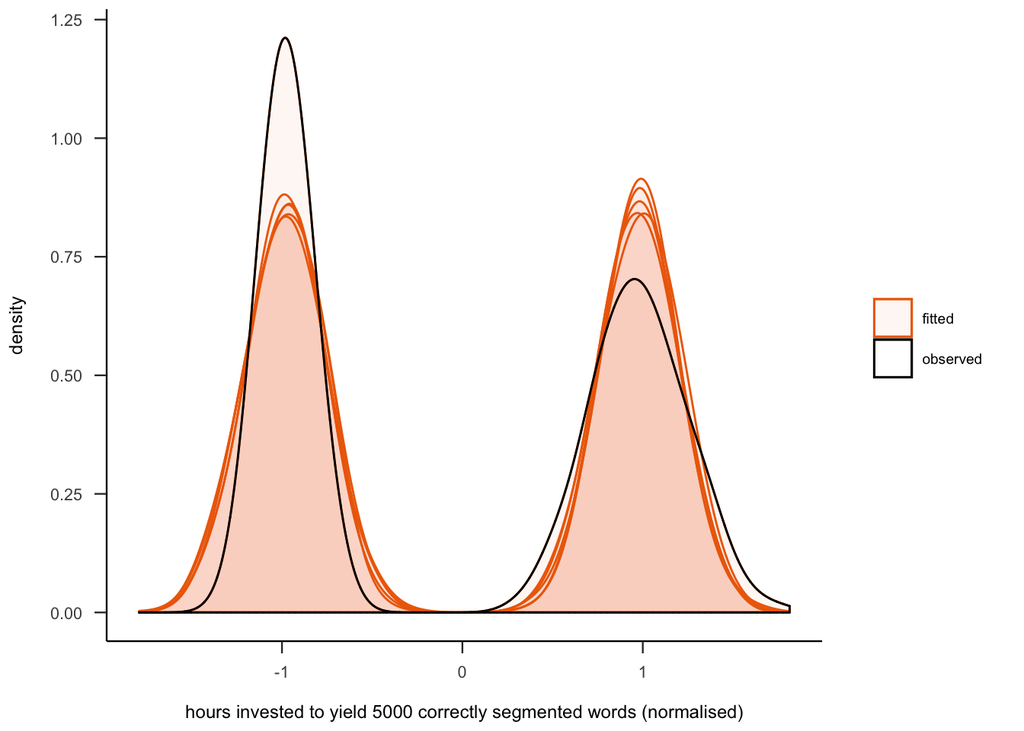

**Figure S11** The posterior-predictive check for Model 2.

```r
if(!file.exists("cached/pp_data_speed.rds")){
  pp_data_speed <- pp_data(m_speed)
  saveRDS(pp_data_speed,"cached/pp_data_speed.rds")
} else {
  pp_data_speed <- readRDS("cached/pp_data_speed.rds")
}

pp_plot_data_speed <- data.frame(y = m_speed$data$`scale(time_investment)`,
                           yrep_1 = pp_data_speed$yrep[1,],
                           yrep_2 = pp_data_speed$yrep[2,],
                           yrep_3 = pp_data_speed$yrep[3,],
                           yrep_4 = pp_data_speed$yrep[4,],
                           yrep_5 = pp_data_speed$yrep[5,]) %>% gather(repetition,.value,y,yrep_1,yrep_2,yrep_3,yrep_4,yrep_5)


pp_plot_speed <- pp_plot_data_speed %>% ggplot()+
  geom_density(aes(x=.value,group=repetition,colour="fitted",fill="fitted"),alpha=0.05,bw=0.1,n=100^2)+
  geom_density(aes(x=.value,colour="observed",fill="observed"),alpha=0,bw=0.1,n=100^2,data=pp_plot_data_speed %>% filter(repetition=="y"))+
  scale_x_continuous("hours invested to yield 5000 correctly segmented words (normalised)")+
  scale_colour_manual("",values=c("observed"="#000000","fitted"="#ED6B06"))+
    scale_fill_manual("",values=c("observed"="#FFFFFF","fitted"="#ED6B06"))
  # coord_cartesian(xlim=c(-5,40))

pp_plot_speed
```

```r
contrast_speed_task <- estimate_contrasts_and_rescale(m_speed,"scale(time_investment)")
contrast_speed_task
```

| Level1 | Level2 | Median | CI_low | CI_high | pd | ROPE_Percentage | Std_Median |
| --- | --- | --- | --- | --- | --- | --- | --- |
| manual | POnSS | 10.64059 | 10.55735 | 10.71989 | 1 | 0 | 1.955167 |

The effect is huge (Cohen’s *d* = 1.96).

Plotting the eyeplots isn’t very useful, since the posteriors are so far apart, here is a plot with both the observed distributions and the eyeplots:

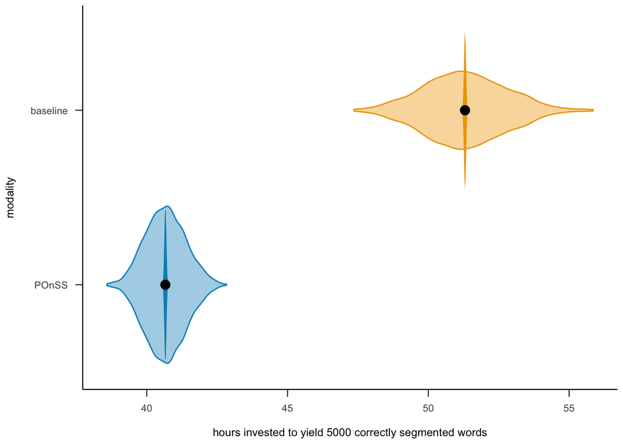

**Figure S12** Distributions of resampled estimates of time investment required to yield 5000 good words by the two modalities (translucent violins). Overlaid are solid violins showing the posteriors of Model 2 for the effect of modality, with median (points), 95% HDIs (thin black lines) and 66% HDIs (thick black lines).

```r
scale_speed <- attr(m_speed$data$`scale(time_investment)`,"scaled:scale")
center_speed <- attr(m_speed$data$`scale(time_investment)`,"scaled:center")

plotdata_speed_task <- m_speed %>% spread_draws(b_task1,b_Intercept) %>%
  group_by(.chain,.iteration,.draw) %>%
  transmute(POnSS = ((b_Intercept - b_task1) * scale_speed) + center_speed,
         manual = ((b_Intercept + b_task1) * scale_speed) + center_speed) %>% gather(task,.value,POnSS,manual)

plot_speed_task <- time_investment_draws %>% ggplot()+
  geom_violinh(aes(x=time_investment,y=task,fill=task,colour=task),alpha=0.4)+
  geom_eyeh(aes(y = task,x=.value,fill=task),data=plotdata_speed_task)+scale_x_continuous("hours invested to yield 5000 correctly segmented words")+
  scale_y_discrete("modality",limits=c("POnSS","manual"),labels=c("POnSS","baseline"))+
  scale_fill_manual(guide=F,"modality",values = c("POnSS"="#008FC1","manual" = "#EEA300"),limits=c("manual","POnSS"),labels=c("baseline","POnSS"))+
  scale_colour_manual(guide=F,"modality",values = c("POnSS"="#008FC1","manual" = "#EEA300"),limits=c("manual","POnSS"),labels=c("baseline","POnSS"))

plot_speed_task
```

```r
# +fillscale_axis(guide=F)+scale_y_discrete("effect of \naxis",limits=c("fast medium","slow medium"),labels = c("fast <-> medium","slow <-> medium"))+scale_x
```

```r
save(plot_speed_task,fes_speed,contrast_speed_task,scale_speed,center_speed,file="report_data/speed_task.RData")
```